# Homework_2

**Group A: Fernandez Santisteban, Marvulli, Spagnolo, Carraro**

```r
library(MASS)
library(DAAG)
```

## DAAG Exercises

Chapter 3 (from page 98), exercises 11, 13.  
Chapter 4 (from page 137), exercises 6, 7.

### Chapter 3, Exercise 11

The following data represent the total number of aberrant crypt foci (abnormal growths in the colon) observed in seven rats that had been administered a single dose of the carcinogen azoxymethane and sacrificed after six weeks (thanks to Ranjana Bird, Faculty of Human Ecology, University of Manitoba for the use of these data):

`87 53 72 90 78 85 83`

Enter these data and compute their sample mean and variance. Is the Poisson model appropriate for these data? To investigate how the sample variance and sample mean differ under the Poisson assumption, repeat the following simulation experiment several times:

```r
x <- rpois(7, 78.3)
mean(x); var(x)
```

**Solution.**

```r
x <- rpois(7, 78.3)
mean(x); var(x)
```

```
## [1] 83.28571
```

```
## [1] 109.5714
```

```r
y <- c(87, 53, 72, 90, 78, 85, 83)

#sample mean:
m <- mean(y)

#sample variance:
s <- var(y)

c(mean=m, var=s)
```

```
##      mean       var
##  78.28571 159.90476
```

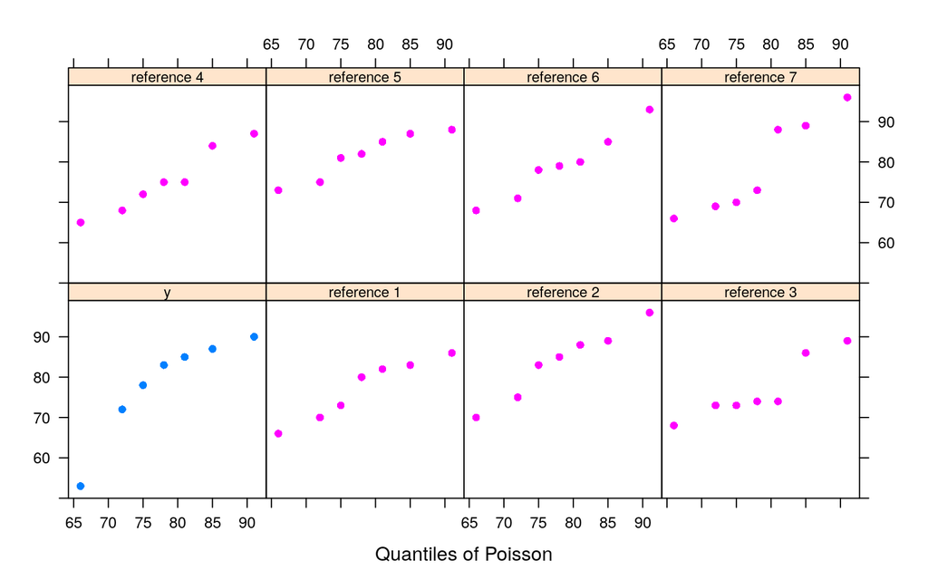

```r
qreference(test = y, nrep = 8, distribution = function(x) qpois(x,
  lambda = ifelse(is.null(y), 0, 78.3)),
  xlab = "Quantiles of Poisson")
```

Since the pink plots are not really like the blue one, maybe the distribution $\mathcal{Po}(78.3)$ is not the right one to model these data.

Let’s investigate further. We take as estimator of the mean the sample mean $\overline{\mu}$ and as estimator of the variance the sample variance $s^2$. Since our assuption is a Poisson distribution, the two values should be equal.

```r
set.seed(4)
R <- 1000 # number of replications

estimator_mean <- c()
estimator_var <- c()
x <- matrix(NA, R, 7)

for (i in 1:R){
  x[i, ] <- rpois(7, 78.3)
  estimator_mean[i] <- mean(x[i, ])
  estimator_var[i] <- var(x[i, ])
}

means <- c(mean(estimator_mean), mean(estimator_var))
means
```

```
## [1] 78.40786 77.20810
```

The two values are in fact near each other.

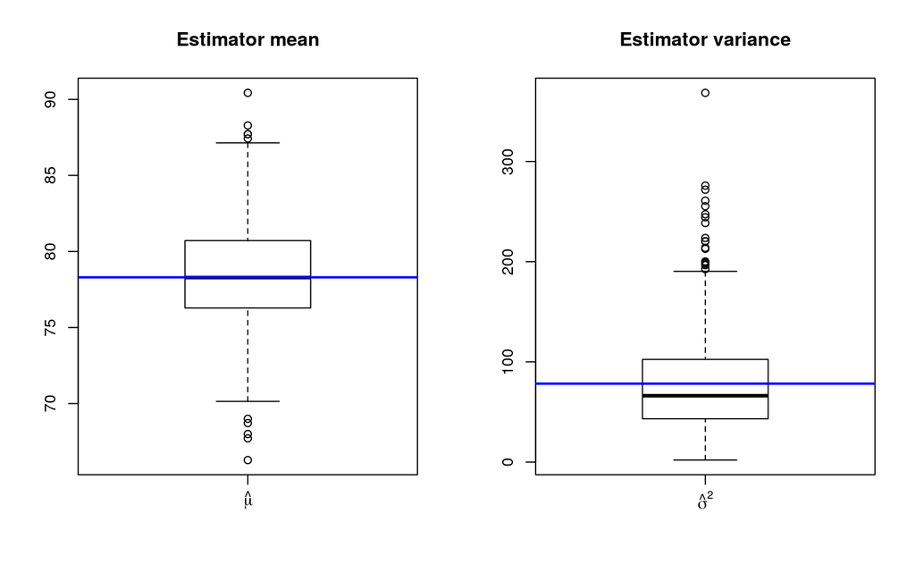

```r
par(mfrow=c(1,2), xaxt="n")
boxplot(estimator_mean, main="Estimator mean")
abline(h=78.3, lwd=2, col="blue")
par(xaxt="s")
axis(1, 1, expression(hat(mu)))
boxplot(estimator_var, main="Estimator variance")
abline(h=78.3, lwd=2, col="blue")
par(xaxt="s")
axis(1, 1, expression(hat(sigma)^2))
```

Let’s check now whether all the estimators are consistent. For checking this statement, $n=7$ is extremely low and we need to increse it, let’s say $n=200$.

```r
estimators_cons <- matrix(NA, R, 2)
n <- 200

for (i in 1:R){
  x <- rpois(n, 78.3)
  estimators_cons[i , 1] <- mean(x)
  estimators_cons[i , 2] <- var(x)
}

variances <- c(var(estimators_cons[, 1]), var(estimators_cons[, 2]))
variances
```

```
## [1]  0.3646193 56.9455652
```

From these values we can see that the efficiency of the sample mean is quite good, since it has a low variance, while the sample variance has a very high variance so it is not so reliable for estimating the parameter $\lambda = 78.3$ of the Poisson distribution.

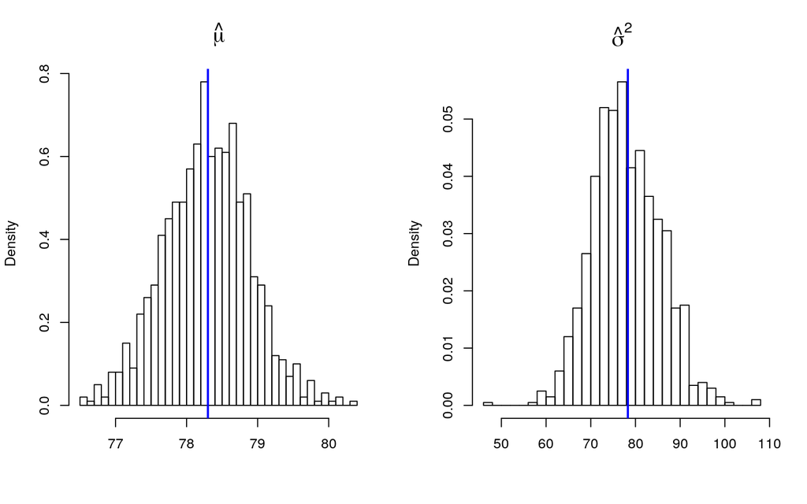

```r
par(mfrow=c(1,2))
hist(estimators_cons[, 1],  probability = TRUE,
     breaks=40, main=substitute(hat(mu)),
     xlab="", cex.main = 1.5)
abline(v=78.3, col="blue", lwd=2)

hist(estimators_cons[, 2],  probability = TRUE,
     breaks=40, main=substitute(hat(sigma)^2),
     xlab="", cex.main = 1.5)
abline(v=78.3, col="blue", lwd=2)
```

We can see that the histogram of the sample mean is less wide in width than the histogram of the sample mean. This tells us that the sample mean is the best estimator for the parameter $\lambda$ in a Poisson distribution.

We can see that the sample mean of our sample is basically equal to the mean of the distribution $\mathcal{Po}(78.3)$, and so it is equal to the value of $\lambda$, but the variance of the former is very far from the variance of the latter.

In conclusion, the Poisson model is **not** appropriate for these data, since in a Poisson distribution mean and variance should coincide, while in our sample `y` the sample variance is double the value of the sample mean.

### Chapter 3, Exercise 13

A Markov chain for the weather in a particular season of the year has the transition matrix, from one day to the next:

$$Pb=
\begin{bmatrix}
& Sun & Cloud & Rain \\
Sun & 0.6 & 0.2 & 0.2\\
Cloud & 0.2 & 0.4 & 0.4\\
Rain & 0.4 & 0.3 & 0.3
\end{bmatrix}$$

It can be shown, using linear algebra, that in the long run this Markov chain will visit the states according to the *stationary* distribution:

| Sun | Cloud | Rain |
| --- | --- | --- |
| 0.641 | 0.208 | 0.151 |

A result called the *ergodic* theorem allows us to estimate this distribution by simulating the Markov chain for a long enough time.

1. Simulate $1000$ values, and calculate the proportion of times the chain visits each of the states. Compare the proportions given by the simulation with the above theoretical proportions.
2. Here is code that calculates rolling averages of the proportions over a number of simulations and plots the result. It uses the function $\mathsf{rollmean()}$ from the $zoo$ package.

$$\begin{align*}
&\mathsf{\text{plotmarkov ←}}\\
&\mathsf{\quad\text{function(n=10000, start=0, window=100, transition=Pb, npanels=5)}}\{\\
&\mathsf{\qquad\text{xc2 ← Markov(n, start, transition)}}\\
&\mathsf{\qquad \text{mav0 ← rollmean(as.integer(xc2==0), window)}}\\
&\mathsf{\qquad \text{mav1 ← rollmean(as.integer(xc2==0), window)}}\\
&\mathsf{\qquad \text{npanel ← cut(1:length(mav0), breaks=seq(from=1, to=length(mav0),}}\\
&\mathsf{\qquad \qquad \qquad \qquad \text{length=npanels+1), include.lowest=TRUE)}}\\
&\mathsf{\qquad \text{df ← data.frame(av0=mav0, av1=mav1, x=1:length(mav0),
gp=npanel)}}\\
&\mathsf{\qquad \text{print(xyplot(av0+av1 ~ x \mid gp, data=df, layout=c(1,npanels),}}\\
&\mathsf{\qquad \qquad \qquad \qquad \text{type="l", par.strip.text=list(cex=0.65),}}\\
&\mathsf{\qquad \qquad \qquad \qquad \text{scales=list(x=list(relation="free"))))}}\\
&\}
\end{align*}$$

Try varying the number of simulations and the width of the window. How wide a window is needed to get a good sense of the stationary distribution? This series settles down rather quickly to its stationary distribution (it “burns in” quite quickly). A reasonable width of window is, however, needed to give an accurate indication of the stationary distribution.

**Solution.**

Looking at the DAAG’s errata corrige (file [link](https://maths-people.anu.edu.au/~johnm/r-book/3edn/updates/updates2011.pdf) at this [page](https://maths-people.anu.edu.au/~johnm/r-book/daagur3.html)) we see that the stationary distribution is wrong. The right real proportions are:

| Sun | Cloud | Rain |
| --- | --- | --- |
| 0.429 | 0.286 | 0.286 |

1. We simulate $1000$ values:

```r
P=matrix(c(0.6, 0.2, 0.4, 0.2, 0.4, 0.3, 0.2, 0.4,0.3 ), 3, 3)

# The following function simulates N values of a Markov chain sequence,
# with transition matrix P
Markov <- function (N=100, initial.value=1, P)
{
  X <- numeric(N)
  X[1] <- initial.value + 1
  n <- nrow(P)
  for (i in 2:N){
    X[i] <- sample(1:n, size=1, prob=P[X[i-1], ])}
  X-1
}

#calculation of the proportions
c <- Markov(1000, 2, P)
b <- vector("numeric", 3)
b <- as.vector(table(c))/length(c)
b
```

```
## [1] 0.442 0.261 0.297
```

Repeating the simulation we see that in general the proportions found are very similar to the real ones.

2. We try varying the number of simulations and the width of the window:

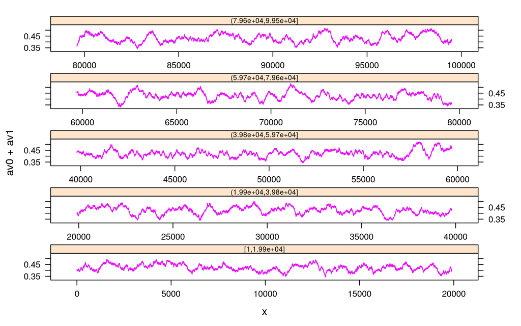

```r
library(zoo)
library(lattice)

plotmarkov <- function(n=100000, start=0, window=500, transition=P, npanels=5){
    xc2 <- Markov(n, start, transition)
    mav0 <- rollmean(as.integer(xc2==0), window)
    mav1 <- rollmean(as.integer(xc2==0), window)
    npanel <- cut(1:length(mav0), breaks=seq(from=1, to=length(mav0),
                 length=npanels+1), include.lowest=TRUE)
    df <- data.frame(av0=mav0, av1=mav1, x=1:length(mav0), gp=npanel)
    print(xyplot(av0+av1 ~ x | gp, data=df, layout=c(1,npanels),
                 type="l", par.strip.text=list(cex=0.65),
                 scales=list(x=list(relation="free"))))
}
plotmarkov()
```

In the context of the so-called “rolling mean”, it is made a mean over the $\mathsf{window}$ previous parameters for each sample. Since in this case the mean is the proportion of states 0 within the window, it can be seen as a sort of local density of states 0. When the Markov chain converges, states evolve according to a stationary distribution with a certain “periodicity” (random fluctuations will have a certain order of magnitude). Actually this can be more complicated as there can be fluctiations with different orders of magnitude overlapping and displayed on a complicated spectrum of frequencies, further to be monocromatic. For this reason, it is important to find out an adeguate ratio among $\mathsf{window}$ and $\mathsf{n}$ parameters. For instance, by setting incorrect values for $\mathsf{n}$ and $\mathsf{window}$, it cannot be observed other than noise (see previous plot). However, by setting a gool balance it boils down to the observance of the convergence.

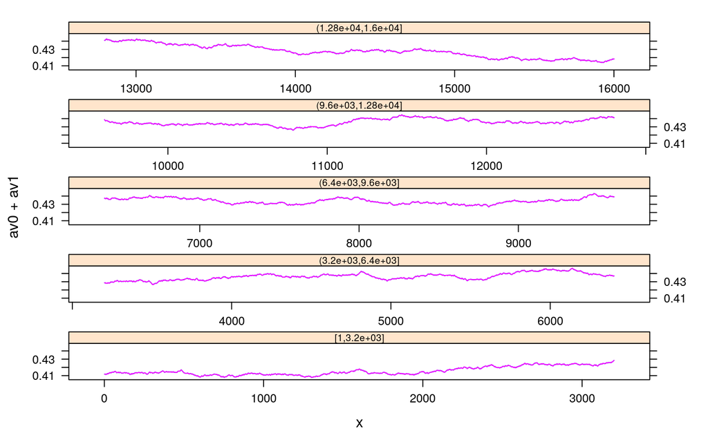

```r
plotmarkov(n=20000, window=4000)
```

In this case, it can be seen clearly that, in the beginning, the curve has much more oscillations while near to the ending it comes more stable. Let’s try to reduce the window of one order of magnitude:

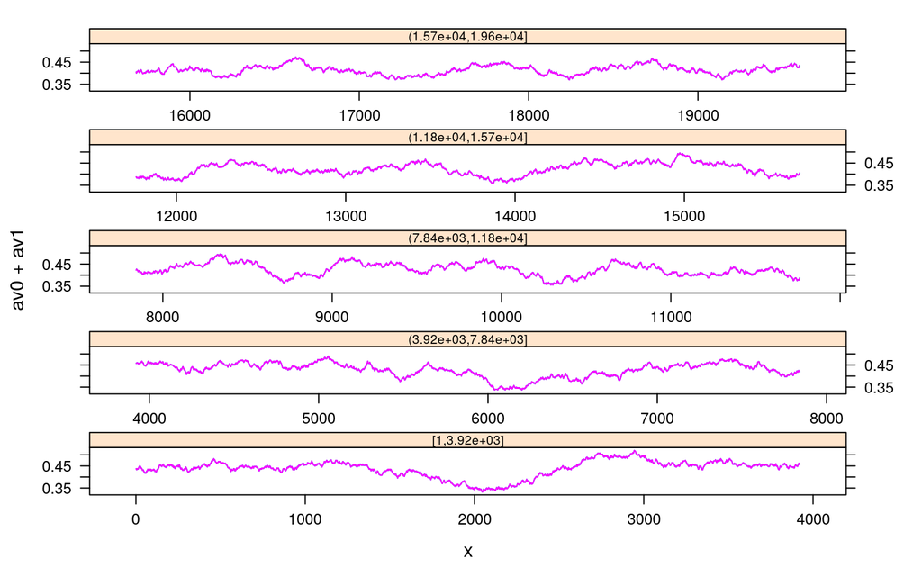

```r
plotmarkov(n=20000, window=400)
```

The plot is completely different, nevertheless, in the ending zone, oscillations have lower amplitude with respect to the beginning, indicating again that there is some convergence. The main conclusion of this little experiment is that the chain convergence (using this kind of plot) can be observed despite its strong dependence on the setting of the parameters. It can be complicated to set up this parameters without any previous knowledge about them. A way to deal with this problem could be to perform previously some kind of spectral decomposition in order to obtain the most dominant frequencies. Then set the parameter $\mathsf{window}$ according to the period associated to these frequencies.

### Chapter 4, Exercise 6

Here we generate random normal numbers with a sequential dependence structure:

$$\begin{align*}
&\mathsf{\text{y1 ← rnorm(51)}}\\
&\mathsf{\text{y ← y1[-1] + y1[-51]}}\\
&\mathsf{\text{acf(y1) # acf is ‘autocorrelation function’}}\\
&\mathsf{\text{ # (see Chapter 9)}}\\
&\mathsf{\text{acf(y)}}
\end{align*}$$

Repeat this several times. There should be no consistent pattern in the $\mathsf{acf}$ plot for different random samples $\mathsf{y1}$. There will be a fairly consistent pattern in the $\mathsf{acf}$ plot for $\mathsf{y}$, a result of the correlation that is introduced by adding to each value the next value in the sequence.

**Solution.**

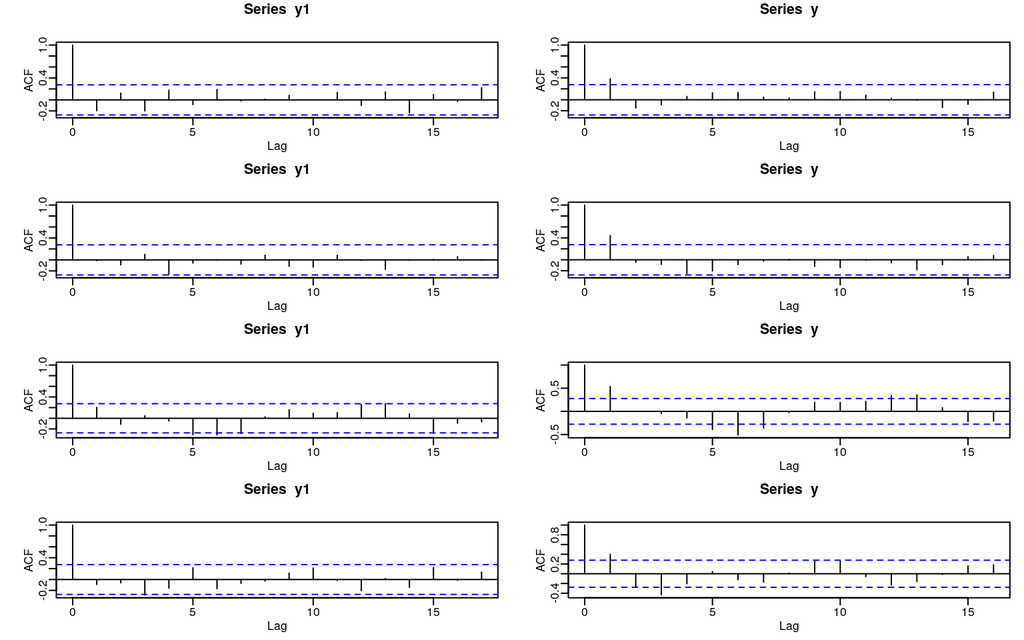

```r
par(mfrow=c(4, 2), mar=c(3,4,3,1), mgp=c(1.5, 0.5, 0))
for(i in 1:4) {
  y1 <- rnorm(51)
  y <- y1[-1] + y1[-51]
  acf(y1)
  acf(y)
}
```

The `correlogram`acf` is a commonly used tool for checking randomness in a data set. This randomness is ascertained by computing autocorrelations for data values at varying time lags. If random, such autocorrelations should be near zero for any and all time-lag separations. If non-random, then one or more of the autocorrelations will be significantly non-zero.

We can see that in the $\mathsf{acf}$ plot for $\mathsf{y1}$ there is no correlation: in the plots the lineas are always under the horizontal blue lines. Instead, in the $\mathsf{acf}$ plot for $\mathsf{y}$ the values sometimes are above or really near the blue lines, particullary the second line, denoting a clear sign of autocorrelation.

### Chapter 4, Exercise 7

Create a function that does the calculations in the first two lines of the previous exercise:

```r
y1 <- rnorm(51)
y <- y1[-1] + y1[-51]
```

Put the calculation in a loop that repeats 25 times. Calculate the mean and variance for each vector $\mathsf{y}$ that is returned. Store the 25 means in the vector $\mathsf{av}$, and store the 25 variances in the vector $\mathsf{v}$. Calculate the variance of $\mathsf{av}$.

**Solution.**

The base implementation of the function is very easy. The point is that this function will be applied several times (passing its input from a matrix). In order to avoid unnecessary loops, before using the function it is neccessary to vectorize it. The vectorized function has been saved with the name $\mathsf{norm\_sample\_general(n)}$ where $\mathsf{n}$ is the number of samples to generate. It is run by setting 51 samples and 25 repetitions and then results are saved on $\mathsf{y}$ matrix.

```r
#function to get n samples
norm_sample <- function(n) {
  y <- rnorm(n);
  y <- y[-1] + y[-n];
  return(y)
}

#vectorization of the previous function
norm_sample_general <- Vectorize(norm_sample)

#get 25 sets of 51 (50) samples
y <- norm_sample_general(rep(51, 25))
y[1:5,1:5]
```

```
##            [,1]        [,2]       [,3]       [,4]        [,5]
## [1,]  0.2849416 -0.06636305  0.7792509  1.8804816 -0.35299704
## [2,]  0.1797887 -0.78204247 -0.8320092  0.6004779  1.26489615
## [3,] -0.7462642 -1.81948595  1.4248159 -1.0888410  2.79324308
## [4,]  0.2615869  0.20037726  3.3595699  0.9562389  0.82412950
## [5,] -0.8496194  1.15190599  0.4398960  1.1743243 -0.04063858
```

Now mean and variance for each column of $\mathsf{y}$ must be computed. In the case of the mean it can be easily computed by applying the function $\mathsf{colMeans()}$ directly to $\mathsf{y}$. However, there is not any function similar to the previous one to calculate the variance (in the $\texttt{R}$ base package). A similar function has been implemented with the name $\mathsf{colVars()}$.

```r
#colVars function
colVars <- function(x) {
  return((colSums(x^2) - colSums(x))/length(x[1,]))
}

#mean and variance of all repetitions
av <- colMeans(y)
v <- colVars(y)

#first 5 means
av[1:5]
```

```
## [1] -0.07957113 -0.19675965  0.11969197  0.14621947 -0.09262297
```

```r
#first 5 variances
v[1:5]
```

```
## [1] 3.610798 4.250336 2.970175 2.853660 3.312958
```

Finally it is computed the variance of the means.

```r
#variance of means
variance <- var(av)
variance
```

```
## [1] 0.1030756
```

## CS Exercises

Chapter 3 (from page 76), exercises 3.3 (hint: use system.time() function), 3.5.

### Exercise 3.3

Rewrite the following, replacing the loop with efficient code:

```r
n <- 100000; z <- rnorm(n)
zneg <- 0; j <- 1
for (i in 1:n) {
  if (z[i]<0) {
    zneg[j] <- z[i]
    j <- j + 1
  }
}
```

Confirm that your rewrite is faster but gives the same result.

**Solution.**

A more efficient code is:

```r
n <- 100000; z <- rnorm(n)

start_time2 <- Sys.time()
zneg2 <- z[which(z < 0)]
end_time2 <- Sys.time()
end_time2 - start_time2
```

```
## Time difference of 0.006188869 secs
```

```r
system.time(zneg2 <- z[which(z < 0)])
```

```
##    user  system elapsed
##   0.001   0.000   0.001
```

While the time of the given code is:

```r
start_time <- Sys.time()
zneg <- 0; j <- 1
for (i in 1:n) {
  if (z[i]<0) {
    zneg[j] <- z[i]
    j <- j + 1
  }
}
end_time <- Sys.time()
end_time - start_time
```

```
## Time difference of 0.03977704 secs
```

```r
system.time({zneg <- 0; j <- 1
for (i in 1:n) {
  if (z[i]<0) {
    zneg[j] <- z[i]
    j <- j + 1
  }
}})
```

```
##    user  system elapsed
##   0.037   0.000   0.038
```

We can see that our code is about one order of magintude faster that the given code.

We have that the two methods give the same result:

```r
identical(zneg2, zneg)
```

```
## [1] TRUE
```

### Exercise 3.5

Consider solving the matrix equation $\mathbf{Ax}=\mathbf{y}$ for $\mathbf{x}$, where $\mathbf{y}$ is a known $n \times n$ matrix. The formal solution to the problem is $\mathbf{x}= \mathbf{A}^{-1} \mathbf{y}$, but it is possible to solve the equation directly, without actually forming $\mathbf{A}^{-1}$. This question explores this direct solution. Read the help file for `solve` before trying it.

1. First create and $\mathbf{A}$, $\mathbf{x}$ and $\mathbf{y}$ satisfying $\mathbf{Ax}=\mathbf{y}$.

```r
set.seed(0); n <- 1000
A <- matrix(runif(n*n),n,n); x.true <- runif(n)
y <- A%*%x.true
```

The idea is to experiment with solving $\mathbf{Ax}=\mathbf{y}$ for $\mathbf{x}$, but with a known truth to compare the answer to.

2. Using `solve`, form the matrix $\mathbf{A}^{-1}$ explicitly and then form $\mathbf{x}_1= \mathbf{A}^{-1} \mathbf{y}$. Note how long this takes. Also assess the mean absolute difference between `x1` and `x.true` (the approximate mean absolute ‘error’ in the solution).
3. Now use `solve` to directly solve for $\mathbf{x}$ without forming $\mathbf{A}^{-1}$. Note how long this takes and assess the mean absolute error of the result.
4. What do you conclude?

**Solution**

1. We create and $\mathbf{A}$, $\mathbf{x}$ and $\mathbf{y}$ satisfying $\mathbf{Ax}=\mathbf{y}$:

```r
library(Metrics)

set.seed(0); n <- 1000
A <- matrix(runif(n*n), n, n);
x.true <- runif(n)
y <- A %*% x.true
```

2. Let’s solve the inverse by using the function `solve(A)` and let’s compute how long it takes throught the function `system.time`.

```r
Ainv <- solve(A)
x1 <- Ainv %*% y
mean(abs(x.true - x1))
```

```
## [1] 2.956833e-11
```

```r
# or
mae(x.true, x1)
```

```
## [1] 2.956833e-11
```

```r
system.time(solve(A) %*% y, gcFirst= TRUE)
```

```
##    user  system elapsed
##   1.412   0.000   1.411
```

3. We use `solve` to directly solve for $\mathbf{x}$ without forming $\mathbf{A}^{-1}$:

```r
x2 <- solve(A, y)
mean(abs(x.true - x2))
```

```
## [1] 1.356142e-12
```

```r
mae(x.true, x2)
```

```
## [1] 1.356142e-12
```

```r
system.time(solve(A, y), gcFirst=TRUE)
```

```
##    user  system elapsed
##   0.403   0.000   0.402
```

4. Through the way exposed in point (b) we get the mean absolute error 2.956833e-11, while through the way exposed in point (c) we get the mean absolute error 1.356142e-12, less than the previous one, which means that it is more precise by roughly one order of magnitude. Moreover, this last solving procedure takes less than the other one in terms of time and so of computational cost (as the result of `system.time` shows). Hence we get that the method of solving $\mathbf{Ax}=\mathbf{y}$ which does not involve the computation of the inverse matrix is more efficient.